# AI/ML SOS IDK

A Beginner-Friendly Machine Learning Workflow in R

## Can we predict the NWSL playoffs? ⚽

Before an NWSL season is over, can we predict which teams will make the playoffs?

We’re going to answer that question with a random forest.

But the model isn’t really the point.

**The workflow is.**

> The algorithm can be interesting. The workflow should be boring.

```r
library(tidymodels)
library(readr)
library(dplyr)
library(ggplot2)
library(knitr)

set.seed(20260914)
```

## 1. Load the data

We’ve already separated our data chronologically:

- **Training:** 2016–2024
- **Testing:** 2025
- **Current season:** 2026

```r
train <- read_csv("data/training_data.csv", show_col_types = FALSE)
test <- read_csv("data/test_data.csv", show_col_types = FALSE)
current <- read_csv("data/current_2026_60.csv", show_col_types = FALSE)
```

## 2. Take a look

A quick sanity check before we build anything: how big are the datasets, and how balanced is the outcome we’re trying to predict?

```r
tibble(
  Dataset = c("Training (2016–2024)", "Testing (2025)", "Current (2026)"),
  Rows = c(nrow(train), nrow(test), nrow(current)),
  `Team-seasons` = c(
    n_distinct(train$team_season_id),
    n_distinct(test$team_season_id),
    n_distinct(current$team_season_id)
  )
) |>
  kable(align = "lrr")
```

| Dataset | Rows | Team-seasons |
| --- | --- | --- |
| Training (2016–2024) | 430 | 86 |
| Testing (2025) | 70 | 14 |
| Current (2026) | 16 | 16 |

```r
train |>
  count(made_playoffs, name = "Snapshots") |>
  kable(
    align = "lr",
    caption = "Training label balance"
  )
```

Training label balance

| made_playoffs | Snapshots |
| --- | --- |
| No | 220 |
| Yes | 210 |

Roughly balanced — no rare-class problem to worry about.

Here is a small snapshot of the modeling data. Each row is one team’s state at a different point in the season; the columns show a few predictors and the outcome we want to predict.

```r
train |>
  filter(
    season == 2016,
    team %in% c("Portland Thorns FC", "Seattle Reign FC")
  ) |>
  arrange(team, checkpoint_pct) |>
  transmute(
    Season = season,
    Team = team,
    `Season completed` = scales::percent(checkpoint_pct, accuracy = 1),
    `Points per game` = round(points_per_game, 2),
    Wins = wins,
    `Made playoffs` = made_playoffs
  ) |>
  kable(
    align = "l",
    caption = "Example rows from the training data",
    table.attr = 'class="data-snapshot"'
  )
```

Example rows from the training data

| Season | Team | Season completed | Points per game | Wins | Made playoffs |
| --- | --- | --- | --- | --- | --- |
| 2016 | Portland Thorns FC | 40% | 1.89 | 4 | Yes |
| 2016 | Portland Thorns FC | 50% | 2.09 | 6 | Yes |
| 2016 | Portland Thorns FC | 60% | 1.86 | 7 | Yes |
| 2016 | Portland Thorns FC | 70% | 1.93 | 8 | Yes |
| 2016 | Portland Thorns FC | 80% | 1.81 | 8 | Yes |
| 2016 | Seattle Reign FC | 40% | 1.38 | 3 | No |
| 2016 | Seattle Reign FC | 50% | 1.30 | 3 | No |
| 2016 | Seattle Reign FC | 60% | 1.31 | 4 | No |
| 2016 | Seattle Reign FC | 70% | 1.33 | 5 | No |
| 2016 | Seattle Reign FC | 80% | 1.44 | 6 | No |

## 3. Preprocess with a recipe

First, we’ll make sure our outcome is treated as a categorical variable.

```r
train <- train |>
  mutate(made_playoffs = factor(made_playoffs, levels = c("Yes", "No")))

test <- test |>
  mutate(made_playoffs = factor(made_playoffs, levels = c("Yes", "No")))
```

Next we’ll define the predictors and transformations using the **recipes** package. Some features are created inside the recipe so the same transformations are applied consistently to future data.

```r
playoff_recipe <- recipe(
  made_playoffs ~
    points +
    wins +
    goal_diff +
    games_played +
    last_5_points +
    last_5_goal_diff +
    points_rank_pct +
    points_gap_to_cutline +
    playoff_share +
    season_pct,
  data = train
) |>
  step_mutate(
    points_per_game = points / games_played,
    win_pct = wins / games_played,
    goal_diff_per_game = goal_diff / games_played
  ) |>
  step_rm(points, wins, goal_diff, games_played) |>
  step_zv(all_predictors())
```

## 4. Specify the model

Now we’ll tell tidymodels what kind of model we want to fit. This is the **parsnip** part of tidymodels — a single, consistent interface for describing models regardless of which engine ends up running them.

```r
rf_spec <- rand_forest(
  trees = 500
) |>
  set_engine("ranger") |>
  set_mode("classification")
```

## 5. Build the workflow

A **workflows** object bundles the preprocessing steps and model specification together.

```r
playoff_workflow <- workflow() |>
  add_recipe(playoff_recipe) |>
  add_model(rf_spec)
```

## 6. Fit the model

Now we can fit the entire workflow to our historical training data.

```r
playoff_fit <- playoff_workflow |>
  fit(data = train)
```

## 7. Evaluate on 2025

Now we’ll test the fitted workflow on the held-out 2025 season.

We’ll make our prediction 60% of the way through the season — early enough that the playoff field isn’t completely settled yet.

```r
test_60 <- test |>
  filter(checkpoint_pct == 0.6)

test_predictions <- predict(
  playoff_fit,
  new_data = test_60,
  type = "prob"
) |>
  bind_cols(
    predict(playoff_fit, new_data = test_60)
  ) |>
  bind_cols(
    test_60 |>
      select(team, made_playoffs)
  ) |>
  arrange(desc(.pred_Yes))
```

The **RF playoff score** shows how strongly the random forest leans toward a playoff outcome. The class prediction just applies a 50% cutoff to that score.

```r
test_predictions |>
  transmute(
    Team = team,
    Actual = made_playoffs,
    Predicted = .pred_class,
    `RF playoff score` = scales::percent(.pred_Yes, accuracy = 1)
  ) |>
  kable(align = "lccr")
```

| Team | Actual | Predicted | RF playoff score |
| --- | --- | --- | --- |
| Kansas City Current | Yes | Yes | 100% |
| San Diego Wave FC | Yes | Yes | 99% |
| Orlando Pride | Yes | Yes | 98% |
| Portland Thorns FC | Yes | Yes | 96% |
| Washington Spirit | Yes | Yes | 96% |
| Racing Louisville FC | Yes | Yes | 88% |
| Seattle Reign FC | Yes | Yes | 86% |
| Gotham FC | Yes | Yes | 53% |
| North Carolina Courage | No | No | 31% |
| Houston Dash | No | No | 17% |
| Angel City FC | No | No | 7% |
| Bay FC | No | No | 7% |
| Chicago Stars FC | No | No | 0% |
| Utah Royals | No | No | 0% |

```r
accuracy(
  test_predictions,
  truth = made_playoffs,
  estimate = .pred_class
) |>
  transmute(Metric = .metric, Value = scales::percent(.estimate, accuracy = 1)) |>
  kable(align = "lr")
```

| Metric | Value |
| --- | --- |
| accuracy | 100% |

```r
conf_mat(
  test_predictions,
  truth = made_playoffs,
  estimate = .pred_class
)
```

```
          Truth
Prediction Yes No
       Yes   8  0
       No    0  6
```

Yes, that says **100%**. No, we have not solved soccer. This is one held-out season at one checkpoint — 14 teams, all classified correctly. Give the model a whole different league, a different year, or an earlier checkpoint and it will start missing. What we can say is that at the 60% mark of the 2025 NWSL season, the workflow got every call right.

## 8. Refit with all historical data

We held out 2025 so we could evaluate our model on data it had never seen.

Now that we’ve done that, we’ll refit the same workflow using all of our completed historical seasons.

```r
all_history <- bind_rows(train, test)

final_fit <- playoff_workflow |>
  fit(data = all_history)
```

## 9. Predict the 2026 playoffs

Finally, we’ll apply our fitted workflow to the 2026 season as it stands today.

```r
current_predictions <- predict(
  final_fit,
  new_data = current,
  type = "prob"
) |>
  bind_cols(
    predict(final_fit, new_data = current)
  ) |>
  bind_cols(
    current |>
      select(team)
  ) |>
  arrange(desc(.pred_Yes))
```

> **A note on the numbers:** the RF playoff score shows how strongly the random forest leans toward a playoff outcome. It’s a model score, not calibrated real-world playoff odds.

```r
current_predictions |>
  transmute(
    Team = team,
    `RF playoff score` = scales::percent(.pred_Yes, accuracy = 1)
  ) |>
  kable(align = "lr")
```

| Team | RF playoff score |
| --- | --- |
| Utah Royals | 100% |
| Gotham FC | 100% |
| Washington Spirit | 99% |
| North Carolina Courage | 98% |
| Kansas City Current | 93% |
| San Diego Wave FC | 92% |
| Portland Thorns FC | 87% |
| Angel City FC | 65% |
| Orlando Pride | 47% |
| Denver Summit FC | 43% |
| Seattle Reign FC | 42% |
| Racing Louisville FC | 17% |
| Bay FC | 15% |
| Boston Legacy FC | 12% |
| Houston Dash | 6% |
| Chicago Stars FC | 1% |

Washington Spirit lands around **99%** — basically every tree in the forest is landing on “playoffs.” The model is very strongly Team Playoffs for Washington. Orlando sits around **47%**, leaning no but much more of a coin-flip.

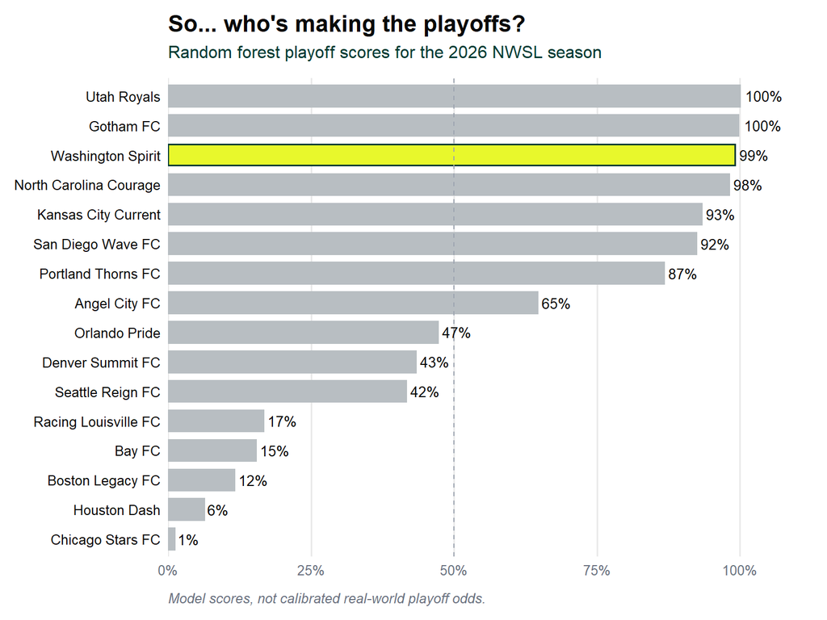

Figure 1: Random forest playoff scores for the 2026 NWSL season. Model scores, not calibrated playoff odds.

```r
spirit_green <- "#003C34"  # deep teal
lemon_venom  <- "#E8F82C"  # vibrant yellow, Washington highlight
spirit_black <- "#0A0A0A"
muted_bar    <- "#B8BEC2"  # quiet gray for the rest of the league

playoff_scores <- current_predictions |>
  transmute(
    team,
    playoff_score = .pred_Yes,
    is_spirit = team == "Washington Spirit"
  ) |>
  arrange(playoff_score) |>
  mutate(team = factor(team, levels = team))

ggplot(
  playoff_scores,
  aes(x = playoff_score, y = team, fill = is_spirit, color = is_spirit)
) +
  geom_col(width = 0.72, linewidth = 0.6) +
  geom_vline(
    xintercept = 0.5,
    linetype = "dashed",
    color = "#9CA3AF",
    linewidth = 0.5
  ) +
  geom_text(
    aes(label = scales::percent(playoff_score, accuracy = 1)),
    hjust = -0.15,
    size = 3.6,
    color = spirit_black
  ) +
  scale_x_continuous(
    labels = scales::percent_format(accuracy = 1),
    limits = c(0, 1.08),
    breaks = seq(0, 1, 0.25),
    expand = expansion(mult = c(0, 0.02))
  ) +
  scale_fill_manual(
    values = c(`TRUE` = lemon_venom, `FALSE` = muted_bar)
  ) +
  scale_color_manual(
    values = c(`TRUE` = spirit_green, `FALSE` = muted_bar)
  ) +
  labs(
    title = "So... who's making the playoffs?",
    subtitle = "Random forest playoff scores for the 2026 NWSL season",
    caption = "Model scores, not calibrated real-world playoff odds.",
    x = NULL,
    y = NULL
  ) +
  theme_minimal(base_size = 12) +
  theme(
    legend.position = "none",
    plot.title = element_text(face = "bold", color = spirit_black, size = 16),
    plot.subtitle = element_text(color = spirit_green, margin = margin(b = 12)),
    plot.caption = element_text(
      color = "#6B7280",
      hjust = 0,
      margin = margin(t = 10),
      face = "italic"
    ),
    axis.text.y = element_text(color = spirit_black),
    axis.text.x = element_text(color = "#6B7280"),
    panel.grid.major.y = element_blank(),
    panel.grid.minor = element_blank(),
    panel.grid.major.x = element_line(color = "#EAEAEA"),
    plot.margin = margin(10, 20, 10, 10)
  )
```